# Exploring Cancer Mutation Data using R

Mark Dunning; Sheffield Bioinformatics Core

Last modified: 21 Jan 2019

# Hello World!

Any R code can be *executed* be placing your cursor on the same and pressing **CTRL** and **ENTER**, or clicking the green triangle on the right of the pane.

**Try this now**

```r
print("Hello World")
```

```
[1] "Hello World"
```

🎉

# Exploring and Visualising Variants in R

R has a rich heritage of packages for manipulating and visualising data and performing statistical analysis. One particular set of packages, the *tidyverse* has gained a lot of attention recently as it supports a lot of common data manipulation operations.

[figure not shown]

This [cheatsheet](https://www.rstudio.com/wp-content/uploads/2015/02/data-wrangling-cheatsheet.pdf) summarises the main data manipulation functions of the package and the [documentation](https://www.tidyverse.org/) is excellent.

The tidyverse functionality is not automatically built into R. We have to load the *tidyverse* library every time we start R.

```r
library(tidyverse)
```

# Cosmic variants

We will illustrate some of the main functions from tidyverse with example data from [COSMIC](https://cancer.sanger.ac.uk/cosmic). An example file is freely available, but you will need to register for full-size file. This is an archive of files. Each has 100 lines of the the full files (that you have to register to access)

`download.file` is an R *function* for downloading a file into your *working directory* (the directory where R is currently looking to open files from, and save files to).

```r
download.file("https://cog.sanger.ac.uk/cosmic/taster/example_grch38_cosmic.tar",destfile = "example_grch38_cosmic.tar")
```

We use R function, `untar` to extract files from the archive. You should see that a `cosmic_example` directory has been created.

```r
untar(tarfile = "example_grch38_cosmic.tar",exdir="cosmic_example")
```

[figure not shown]

We import data so that we can analyse it in R using one of the various functions that are called `read_..`. The choice depends on the type of file (csv, tsv, etc…)

```r
mutants <- read_tsv("cosmic_example/CosmicMutantExport.tsv")
```

The `<-` symbol means that we are storing the data in R’s memory for future use. Whenever we want to see what the data look like, or manipulate them, we can use the name of the *“variable”* that we have specified; `mutants`.

This prints the data to the screen, but in a clever way so that we can cycle through the entries.

```r
mutants
```

| Gene name | Accession Number | Gene CDS length | HGNC ID | Sample name | ID_sample | ID_tumour | Primary site | Site subtype 1 | Site subtype 2 | Site subtype 3 | Primary histology | Histology subtype 1 | Histology subtype 2 | Histology subtype 3 | Genome-wide screen | Mutation ID | Mutation CDS | Mutation AA | Mutation Description | Mutation zygosity | LOH | GRCh | Mutation genome position | Mutation strand | SNP | Resistance Mutation | FATHMM prediction | FATHMM score | Mutation somatic status | … |
| --- | --- | --- | --- | --- | --- | --- | --- | --- | --- | --- | --- | --- | --- | --- | --- | --- | --- | --- | --- | --- | --- | --- | --- | --- | --- | --- | --- | --- | --- | --- |
| GRK6 | ENST00000355472 | 1731 | 4545 | PD1403a | 898155 | 815769 | stomach | NS | NS | NS | carcinoma | adenocarcinoma | NS | NS | n | COSM20611 | c.92G>A | p.R31Q | Substitution - Missense | het | n | 38 | 5:177430911-177430911 | + | n | - | PATHOGENIC | 0.89562 | Confirmed somatic variant | … |
| TMEM108 | ENST00000321871 | 1728 | 28451 | TCGA-13-0760-01 | 1474815 | 1398514 | ovary | NS | NS | NS | carcinoma | serous_carcinoma | NS | NS | y | COSM76748 | c.1289T>A | p.L430H | Substitution - Missense | het | u | 38 | 3:133381000-133381000 | + | n | - | PATHOGENIC | 0.96095 | Confirmed somatic variant | … |
| HRH1 | ENST00000397056 | 1464 | 5182 | TCGA-13-0900-01 | 1474861 | 1398560 | ovary | NS | NS | NS | carcinoma | serous_carcinoma | NS | NS | y | COSM77864 | c.67G>T | p.A23S | Substitution - Missense | het | u | 38 | 3:11259104-11259104 | + | n | - | NEUTRAL | 0.19219 | Confirmed somatic variant | … |
| SLC26A8 | ENST00000355574 | 2913 | 14468 | TCGA-13-1509-01 | 1474839 | 1398538 | ovary | NS | NS | NS | carcinoma | serous_carcinoma | NS | NS | y | COSM76465 | c.2890G>A | p.G964S | Substitution - Missense | het | u | 38 | 6:35943923-35943923 | - | n | - | NEUTRAL | 0.01336 | Confirmed somatic variant | … |
| OR51E1 | ENST00000396952 | 957 | 15194 | GC1_T | 1645677 | 1560711 | stomach | NS | NS | NS | carcinoma | adenocarcinoma | NS | NS | y | COSM147110 | c.408C>G | p.A136A | Substitution - coding silent | het | u | 38 | 11:4652934-4652934 | + | n | - | NEUTRAL | 0.06727 | Variant of unknown origin | … |
| CMYA5 | ENST00000238522 | 11259 | NA | TCGA-AG-3892-01 | 1651564 | 1566351 | large_intestine | rectum | NS | NS | carcinoma | adenocarcinoma | NS | NS | y | COSM256649 | c.4237C>A | p.L1413I | Substitution - Missense | NA | u | 38 | 5:79733002-79733002 | + | n | - | NEUTRAL | 0.16592 | Confirmed somatic variant | … |
| SNAP91 | ENST00000369694 | 2724 | 14986 | TCGA-AG-A002-01 | 1651648 | 1566435 | large_intestine | rectum | NS | NS | carcinoma | adenocarcinoma | NS | NS | y | COSM263793 | c.196C>T | p.R66W | Substitution - Missense | NA | u | 38 | 6:83665516-83665516 | - | n | - | PATHOGENIC | 0.86988 | Confirmed somatic variant | … |
| ZDBF2 | ENST00000374423 | 7065 | 29313 | TCGA-AG-A01W-01 | 1651660 | 1566447 | large_intestine | rectum | NS | NS | carcinoma | adenocarcinoma | NS | NS | y | COSM290225 | c.156G>T | p.L52L | Substitution - coding silent | NA | u | 38 | 2:206297341-206297341 | + | n | - | NEUTRAL | 0.09086 | Confirmed somatic variant | … |
| FOXA2 | ENST00000377115 | 1374 | 5022 | TCGA-AA-3844-01 | 1651046 | 1565833 | large_intestine | colon | sigmoid | NS | carcinoma | adenocarcinoma | NS | NS | y | COSM295272 | c.545T>A | p.L182Q | Substitution - Missense | NA | u | 38 | 20:22582679-22582679 | - | n | - | PATHOGENIC | 0.99467 | Confirmed somatic variant | … |
| CMYA5 | ENST00000238522 | 11259 | NA | TCGA-AG-A002-01 | 1651648 | 1566435 | large_intestine | rectum | NS | NS | carcinoma | adenocarcinoma | NS | NS | y | COSM260156 | c.1567G>T | p.D523Y | Substitution - Missense | NA | u | 38 | 5:79730332-79730332 | + | n | - | NEUTRAL | 0.13058 | Confirmed somatic variant | … |

[output cut: 89 more lines]

`mutants` is an example of a *data frame*, which is R’s way of storing tabular data where we potentially have different types of data (text, numbers, dates) in each column.

## `Select`ing columns

We can use the `select` function to print only the columns we are interested in by listing their names with a `,` in between. Column names with a space need to have single quote marks around them ```

```r
select(mutants, `Gene name`, `Primary site`, `Mutation ID`)
```

| Gene name | Primary site | Mutation ID |
| --- | --- | --- |
| GRK6 | stomach | COSM20611 |
| TMEM108 | ovary | COSM76748 |
| HRH1 | ovary | COSM77864 |
| SLC26A8 | ovary | COSM76465 |
| OR51E1 | stomach | COSM147110 |
| CMYA5 | large_intestine | COSM256649 |
| SNAP91 | large_intestine | COSM263793 |
| ZDBF2 | large_intestine | COSM290225 |
| FOXA2 | large_intestine | COSM295272 |
| CMYA5 | large_intestine | COSM260156 |

[output cut: 89 more lines]

If the columns we want are consecutive there is a handy shortcut of `:`

```r
select(mutants, `Gene name`:`Sample name`)
```

| Gene name | Accession Number | Gene CDS length | HGNC ID | Sample name |
| --- | --- | --- | --- | --- |
| GRK6 | ENST00000355472 | 1731 | 4545 | PD1403a |
| TMEM108 | ENST00000321871 | 1728 | 28451 | TCGA-13-0760-01 |
| HRH1 | ENST00000397056 | 1464 | 5182 | TCGA-13-0900-01 |
| SLC26A8 | ENST00000355574 | 2913 | 14468 | TCGA-13-1509-01 |
| OR51E1 | ENST00000396952 | 957 | 15194 | GC1_T |
| CMYA5 | ENST00000238522 | 11259 | NA | TCGA-AG-3892-01 |
| SNAP91 | ENST00000369694 | 2724 | 14986 | TCGA-AG-A002-01 |
| ZDBF2 | ENST00000374423 | 7065 | 29313 | TCGA-AG-A01W-01 |
| FOXA2 | ENST00000377115 | 1374 | 5022 | TCGA-AA-3844-01 |
| CMYA5 | ENST00000238522 | 11259 | NA | TCGA-AG-A002-01 |

[output cut: 89 more lines]

Or if we known that the columns all have a particular name in common.

```r
select(mutants, contains("Mutation"))
```

| Mutation ID | Mutation CDS | Mutation AA | Mutation Description | Mutation zygosity | Mutation genome position | Mutation strand | Resistance Mutation | Mutation somatic status |
| --- | --- | --- | --- | --- | --- | --- | --- | --- |
| COSM20611 | c.92G>A | p.R31Q | Substitution - Missense | het | 5:177430911-177430911 | + | - | Confirmed somatic variant |
| COSM76748 | c.1289T>A | p.L430H | Substitution - Missense | het | 3:133381000-133381000 | + | - | Confirmed somatic variant |
| COSM77864 | c.67G>T | p.A23S | Substitution - Missense | het | 3:11259104-11259104 | + | - | Confirmed somatic variant |
| COSM76465 | c.2890G>A | p.G964S | Substitution - Missense | het | 6:35943923-35943923 | - | - | Confirmed somatic variant |
| COSM147110 | c.408C>G | p.A136A | Substitution - coding silent | het | 11:4652934-4652934 | + | - | Variant of unknown origin |
| COSM256649 | c.4237C>A | p.L1413I | Substitution - Missense | NA | 5:79733002-79733002 | + | - | Confirmed somatic variant |
| COSM263793 | c.196C>T | p.R66W | Substitution - Missense | NA | 6:83665516-83665516 | - | - | Confirmed somatic variant |
| COSM290225 | c.156G>T | p.L52L | Substitution - coding silent | NA | 2:206297341-206297341 | + | - | Confirmed somatic variant |
| COSM295272 | c.545T>A | p.L182Q | Substitution - Missense | NA | 20:22582679-22582679 | - | - | Confirmed somatic variant |
| COSM260156 | c.1567G>T | p.D523Y | Substitution - Missense | NA | 5:79730332-79730332 | + | - | Confirmed somatic variant |

[output cut: 89 more lines]

## `filter`ing the rows

The `select` function prints all the rows to the screen. There are many ocassions when we might want to print rows that meet a certain criteria.

*e.g. to find all mutations that are pathogenic.*

The `==` symbol is used to test what entries in the `FATHMM prediction` column are the same as `PATHOGENIC`

```r
filter(mutants, `FATHMM prediction`=="PATHOGENIC")
```

| Gene name | Accession Number | Gene CDS length | HGNC ID | Sample name | ID_sample | ID_tumour | Primary site | Site subtype 1 | Site subtype 2 | Site subtype 3 | Primary histology | Histology subtype 1 | Histology subtype 2 | Histology subtype 3 | Genome-wide screen | Mutation ID | Mutation CDS | Mutation AA | Mutation Description | Mutation zygosity | LOH | GRCh | Mutation genome position | Mutation strand | SNP | Resistance Mutation | FATHMM prediction | FATHMM score | Mutation somatic status | … |
| --- | --- | --- | --- | --- | --- | --- | --- | --- | --- | --- | --- | --- | --- | --- | --- | --- | --- | --- | --- | --- | --- | --- | --- | --- | --- | --- | --- | --- | --- | --- |
| GRK6 | ENST00000355472 | 1731 | 4545 | PD1403a | 898155 | 815769 | stomach | NS | NS | NS | carcinoma | adenocarcinoma | NS | NS | n | COSM20611 | c.92G>A | p.R31Q | Substitution - Missense | het | n | 38 | 5:177430911-177430911 | + | n | - | PATHOGENIC | 0.89562 | Confirmed somatic variant | … |
| TMEM108 | ENST00000321871 | 1728 | 28451 | TCGA-13-0760-01 | 1474815 | 1398514 | ovary | NS | NS | NS | carcinoma | serous_carcinoma | NS | NS | y | COSM76748 | c.1289T>A | p.L430H | Substitution - Missense | het | u | 38 | 3:133381000-133381000 | + | n | - | PATHOGENIC | 0.96095 | Confirmed somatic variant | … |
| SNAP91 | ENST00000369694 | 2724 | 14986 | TCGA-AG-A002-01 | 1651648 | 1566435 | large_intestine | rectum | NS | NS | carcinoma | adenocarcinoma | NS | NS | y | COSM263793 | c.196C>T | p.R66W | Substitution - Missense | NA | u | 38 | 6:83665516-83665516 | - | n | - | PATHOGENIC | 0.86988 | Confirmed somatic variant | … |
| FOXA2 | ENST00000377115 | 1374 | 5022 | TCGA-AA-3844-01 | 1651046 | 1565833 | large_intestine | colon | sigmoid | NS | carcinoma | adenocarcinoma | NS | NS | y | COSM295272 | c.545T>A | p.L182Q | Substitution - Missense | NA | u | 38 | 20:22582679-22582679 | - | n | - | PATHOGENIC | 0.99467 | Confirmed somatic variant | … |
| AK7 | ENST00000267584 | 2172 | 20091 | TCGA-AA-A00N-01 | 1651102 | 1565889 | large_intestine | caecum | NS | NS | carcinoma | adenocarcinoma | NS | NS | y | COSM273928 | c.2042G>A | p.R681K | Substitution - Missense | NA | u | 38 | 14:96486965-96486965 | + | n | - | PATHOGENIC | 0.96628 | Confirmed somatic variant | … |
| RNFT1_ENST00000305783 | ENST00000305783 | 1308 | NA | PD11766a | 1768248 | 1672497 | breast | NS | NS | NS | carcinoma | ductal_carcinoma | NS | NS | y | COSM5795674 | c.924C>T | p.Y308Y | Substitution - coding silent | NA | u | 38 | 17:59957305-59957305 | - | n | - | PATHOGENIC | 0.70684 | Confirmed somatic variant | … |
| ARSB | ENST00000264914 | 1602 | 714 | TCGA-B0-4700-01 | 1779807 | 1683806 | kidney | NS | NS | NS | carcinoma | clear_cell_renal_cell_carcinoma | NS | NS | y | COSM483068 | c.1144G>A | p.E382K | Substitution - Missense | NA | u | 38 | 5:78839425-78839425 | - | n | - | PATHOGENIC | 0.87518 | Confirmed somatic variant | … |
| TFE3_ENST00000336239 | ENST00000336239 | 2229 | NA | TCGA-B5-A0K9-01 | 1783398 | 1687397 | endometrium | NS | NS | NS | carcinoma | endometrioid_carcinoma | NS | NS | y | COSM1122323 | c.497G>A | p.R166H | Substitution - Missense | NA | u | 38 | 23:49039144-49039144 | - | n | - | PATHOGENIC | 0.92212 | Confirmed somatic variant | … |
| PPL | ENST00000345988 | 5271 | 9273 | TCGA-D1-A17F-01 | 1783527 | 1687526 | endometrium | NS | NS | NS | carcinoma | endometrioid_carcinoma | NS | NS | y | COSM971105 | c.4698C>A | p.H1566Q | Substitution - Missense | NA | u | 38 | 16:4883957-4883957 | - | n | - | PATHOGENIC | 0.98724 | Confirmed somatic variant | … |
| TIAM1_ENST00000286827 | ENST00000286827 | 4776 | NA | TCGA-BG-A187-01 | 1783449 | 1687448 | endometrium | NS | NS | NS | carcinoma | endometrioid_carcinoma | NS | NS | y | COSM1029963 | c.4306G>A | p.V1436M | Substitution - Missense | NA | u | 38 | 21:31124522-31124522 | - | n | - | PATHOGENIC | 0.97735 | Confirmed somatic variant | … |

[output cut: 49 more lines]

Similar example but looking for a given gene

```r
filter(mutants, `Gene name`=="CMYA5")
```

| Gene name | Accession Number | Gene CDS length | HGNC ID | Sample name | ID_sample | ID_tumour | Primary site | Site subtype 1 | Site subtype 2 | Site subtype 3 | Primary histology | Histology subtype 1 | Histology subtype 2 | Histology subtype 3 | Genome-wide screen | Mutation ID | Mutation CDS | Mutation AA | Mutation Description | Mutation zygosity | LOH | GRCh | Mutation genome position | Mutation strand | SNP | Resistance Mutation | FATHMM prediction | FATHMM score | Mutation somatic status | … |
| --- | --- | --- | --- | --- | --- | --- | --- | --- | --- | --- | --- | --- | --- | --- | --- | --- | --- | --- | --- | --- | --- | --- | --- | --- | --- | --- | --- | --- | --- | --- |
| CMYA5 | ENST00000238522 | 11259 | NA | TCGA-AG-3892-01 | 1651564 | 1566351 | large_intestine | rectum | NS | NS | carcinoma | adenocarcinoma | NS | NS | y | COSM256649 | c.4237C>A | p.L1413I | Substitution - Missense | NA | u | 38 | 5:79733002-79733002 | + | n | - | NEUTRAL | 0.16592 | Confirmed somatic variant | … |
| CMYA5 | ENST00000238522 | 11259 | NA | TCGA-AG-A002-01 | 1651648 | 1566435 | large_intestine | rectum | NS | NS | carcinoma | adenocarcinoma | NS | NS | y | COSM260156 | c.1567G>T | p.D523Y | Substitution - Missense | NA | u | 38 | 5:79730332-79730332 | + | n | - | NEUTRAL | 0.13058 | Confirmed somatic variant | … |

`filter` can also be used when we have numeric data

*e.g. what mutations occur in individuals under 50*

```r
filter(mutants, Age<50)
```

| Gene name | Accession Number | Gene CDS length | HGNC ID | Sample name | ID_sample | ID_tumour | Primary site | Site subtype 1 | Site subtype 2 | Site subtype 3 | Primary histology | Histology subtype 1 | Histology subtype 2 | Histology subtype 3 | Genome-wide screen | Mutation ID | Mutation CDS | Mutation AA | Mutation Description | Mutation zygosity | LOH | GRCh | Mutation genome position | Mutation strand | SNP | Resistance Mutation | FATHMM prediction | FATHMM score | Mutation somatic status | … |
| --- | --- | --- | --- | --- | --- | --- | --- | --- | --- | --- | --- | --- | --- | --- | --- | --- | --- | --- | --- | --- | --- | --- | --- | --- | --- | --- | --- | --- | --- | --- |
| SNAP91 | ENST00000369694 | 2724 | 14986 | TCGA-AG-A002-01 | 1651648 | 1566435 | large_intestine | rectum | NS | NS | carcinoma | adenocarcinoma | NS | NS | y | COSM263793 | c.196C>T | p.R66W | Substitution - Missense | NA | u | 38 | 6:83665516-83665516 | - | n | - | PATHOGENIC | 0.86988 | Confirmed somatic variant | … |
| CMYA5 | ENST00000238522 | 11259 | NA | TCGA-AG-A002-01 | 1651648 | 1566435 | large_intestine | rectum | NS | NS | carcinoma | adenocarcinoma | NS | NS | y | COSM260156 | c.1567G>T | p.D523Y | Substitution - Missense | NA | u | 38 | 5:79730332-79730332 | + | n | - | NEUTRAL | 0.13058 | Confirmed somatic variant | … |
| C12orf41_ENST00000420613 | ENST00000420613 | 1479 | NA | TCGA-CJ-4908-01 | 1779978 | 1683977 | kidney | NS | NS | NS | carcinoma | clear_cell_renal_cell_carcinoma | NS | NS | y | COSM468417 | c.1361T>G | p.M454R | Substitution - Missense | NA | u | 38 | 12:48654162-48654162 | - | n | - | NEUTRAL | 0.37378 | Confirmed somatic variant | … |
| INTS5 | ENST00000330574 | 3060 | 29352 | TCGA-AP-A0LM-01 | 1783352 | 1687351 | endometrium | NS | NS | NS | carcinoma | endometrioid_carcinoma | NS | NS | y | COSM929759 | c.2311G>A | p.E771K | Substitution - Missense | het | u | 38 | 11:62647769-62647769 | - | n | - | PATHOGENIC | 0.89469 | Variant of unknown origin | … |
| FAM83D | ENST00000217429 | 1848 | 16122 | D85T | 2745037 | 2603740 | thyroid | NS | NS | NS | carcinoma | NS | NS | NS | y | COSM6391858 | c.341C>T | p.A114V | Substitution - Missense | NA | u | 38 | 20:38926693-38926693 | + | n | - | PATHOGENIC | 0.91343 | Confirmed somatic variant | … |
| C6orf27 | ENST00000375688 | 2676 | 13939 | W41T | 2745059 | 2603762 | thyroid | NS | NS | NS | carcinoma | NS | NS | NS | y | COSM6400475 | c.862T>C | p.S288P | Substitution - Missense | NA | u | 38 | 6:31773297-31773297 | - | n | - | PATHOGENIC | 0.80071 | Confirmed somatic variant | … |
| PIK3C2B | ENST00000367187 | 4905 | 8972 | TCGA-08-0357-01 | 1910233 | 1798524 | central_nervous_system | brain | NS | NS | glioma | astrocytoma_Grade_IV | glioblastoma_multiforme | NS | y | COSM1559277 | c.121C>G | p.R41G | Substitution - Missense | hom | u | 38 | 1:204469682-204469682 | - | n | - | PATHOGENIC | 0.94521 | Variant of unknown origin | … |
| EPM2A | ENST00000367519 | 996 | 3413 | W2T | 2745039 | 2603742 | thyroid | NS | NS | NS | carcinoma | NS | NS | NS | y | COSM6360035 | c.838T>C | p.W280R | Substitution - Missense | NA | u | 38 | 6:145627574-145627574 | - | n | - | PATHOGENIC | 0.95717 | Confirmed somatic variant | … |
| SYNE1_ENST00000265368 | ENST00000265368 | 26394 | NA | W2T | 2745039 | 2603742 | thyroid | NS | NS | NS | carcinoma | NS | NS | NS | y | COSM6362882 | c.22594G>T | p.E7532* | Substitution - Nonsense | NA | u | 38 | 6:152208202-152208202 | - | n | - | PATHOGENIC | 0.86677 | Confirmed somatic variant | … |
| RSPH1 | ENST00000291536 | 930 | 12371 | TCGA-AP-A0LM-01 | 1783352 | 1687351 | endometrium | NS | NS | NS | carcinoma | endometrioid_carcinoma | NS | NS | y | COSM1031062 | c.594G>T | p.E198D | Substitution - Missense | het | u | 38 | 21:42477424-42477424 | - | n | - | NEUTRAL | 0.24658 | Variant of unknown origin | … |

[output cut: 5 more lines]

## Modifying the columns

The `mutate` function can be used to add new columns based on existing ones. An extremely useful function is `separate` that can split columns that appear to contain more than one piece of information.

*e.g. extract chromosome, start and end from the genome location*

```r
mutants <- separate(mutants, `Mutation genome position`, into= c("Chromosome","Start","End"))
```

## Sorting the data

Data can be sorted according to column with the `arrange` function; either ascending of descending

```r
arrange(mutants, `Gene CDS length`)
```

| Gene name | Accession Number | Gene CDS length | HGNC ID | Sample name | ID_sample | ID_tumour | Primary site | Site subtype 1 | Site subtype 2 | Site subtype 3 | Primary histology | Histology subtype 1 | Histology subtype 2 | Histology subtype 3 | Genome-wide screen | Mutation ID | Mutation CDS | Mutation AA | Mutation Description | Mutation zygosity | LOH | GRCh | Chromosome | Start | End | Mutation strand | SNP | Resistance Mutation | FATHMM prediction | … |
| --- | --- | --- | --- | --- | --- | --- | --- | --- | --- | --- | --- | --- | --- | --- | --- | --- | --- | --- | --- | --- | --- | --- | --- | --- | --- | --- | --- | --- | --- | --- |
| XAGE3 | ENST00000375491 | 336 | 14618 | tumor_4101316 | 2121008 | 1995244 | haematopoietic_and_lymphoid_tissue | NS | NS | NS | lymphoid_neoplasm | NS | NS | NS | y | COSM3357446 | c.81+10T>C | p.? | Unknown | NA | u | 38 | 23 | 52867043 | 52867043 | - | n | - | NEUTRAL | … |
| PTRHD1 | ENST00000328379 | 423 | 33782 | TCGA-EE-A20C-06 | 2121628 | 1995864 | skin | NS | NS | NS | malignant_melanoma | NS | NS | NS | y | COSM3580234 | c.246C>T | p.V82V | Substitution - coding silent | NA | u | 38 | 2 | 24793132 | 24793132 | - | n | - | NEUTRAL | … |
| LECT2 | ENST00000274507 | 456 | 6550 | CPCG0184-P3 | 2121438 | 1995674 | prostate | NS | NS | NS | carcinoma | adenocarcinoma | NS | NS | y | COSM1130934 | c.172A>G | p.I58V | Substitution - Missense | NA | u | 38 | 5 | 135951340 | 135951340 | - | y | - | NEUTRAL | … |
| NMU | ENST00000264218 | 525 | 7859 | AOCS-135-8-X | 2186429 | 2054726 | ovary | NS | NS | NS | carcinoma | mixed_adenosquamous_carcinoma | NS | NS | y | COSM4135816 | c.105C>T | p.A35A | Substitution - coding silent | NA | u | 38 | 4 | 55636088 | 55636088 | - | n | - | NEUTRAL | … |
| CLEC2D_ENST00000290855 | ENST00000290855 | 576 | 14351 | TCGA-AP-A051-01 | 1783330 | 1687329 | endometrium | NS | NS | NS | carcinoma | endometrioid_carcinoma | NS | NS | y | COSM944811 | c.109C>T | p.R37C | Substitution - Missense | het | u | 38 | 12 | 9680970 | 9680970 | + | n | - | NEUTRAL | … |
| IL37_ENST00000311328 | ENST00000311328 | 579 | 15563 | TCGA-EE-A2A1-06 | 2121650 | 1995886 | skin | NS | NS | NS | malignant_melanoma | NS | NS | NS | y | COSM3565401 | c.76G>A | p.V26M | Substitution - Missense | NA | u | 38 | 2 | 112917137 | 112917137 | + | n | - | NEUTRAL | … |
| PITHD1 | ENST00000246151 | 636 | 25022 | 100-02-2TD | 1921412 | 1808730 | haematopoietic_and_lymphoid_tissue | NS | NS | NS | lymphoid_neoplasm | chronic_lymphocytic_leukaemia-small_lymphocytic_lymphoma | NS | NS | y | COSM7207735 | c.452_454delATC | p.H151delH | Deletion - In frame | NA | u | 38 | 1 | 23786341 | 23786343 | + | NA | - | NA | … |
| ADAMTS12_ENST00000515401 | ENST00000515401 | 699 | 14605 | TCGA-AA-3672-01 | 1651015 | 1565802 | large_intestine | colon | transverse | NS | carcinoma | adenocarcinoma | NS | NS | y | COSM265965 | c.89C>A | p.P30H | Substitution - Missense | NA | u | 38 | 5 | 33891768 | 33891768 | - | n | - | NA | … |
| AC093393.1 | ENST00000322472 | 738 | NA | TCGA-BS-A0UM-01 | 1783476 | 1687475 | endometrium | NS | NS | NS | carcinoma | endometrioid_carcinoma | NS | NS | y | COSM1020562 | c.258C>T | p.G86G | Substitution - coding silent | NA | u | 38 | 2 | 33727518 | 33727518 | - | n | - | NEUTRAL | … |
| HDGF_ENST00000368206 | ENST00000368206 | 771 | 4856 | TCGA-39-5037-01 | 1781591 | 1685590 | lung | NS | NS | NS | carcinoma | squamous_cell_carcinoma | NS | NS | y | COSM1145975 | c.574G>A | p.E192K | Substitution - Missense | NA | u | 38 | 1 | 156743842 | 156743842 | - | n | - | PATHOGENIC | … |

[output cut: 89 more lines]

```r
arrange(mutants, desc(`Gene CDS length`))
```

| Gene name | Accession Number | Gene CDS length | HGNC ID | Sample name | ID_sample | ID_tumour | Primary site | Site subtype 1 | Site subtype 2 | Site subtype 3 | Primary histology | Histology subtype 1 | Histology subtype 2 | Histology subtype 3 | Genome-wide screen | Mutation ID | Mutation CDS | Mutation AA | Mutation Description | Mutation zygosity | LOH | GRCh | Chromosome | Start | End | Mutation strand | SNP | Resistance Mutation | FATHMM prediction | … |
| --- | --- | --- | --- | --- | --- | --- | --- | --- | --- | --- | --- | --- | --- | --- | --- | --- | --- | --- | --- | --- | --- | --- | --- | --- | --- | --- | --- | --- | --- | --- |
| MUC16_ENST00000397910 | ENST00000397910 | 43524 | NA | CPCG0184-P4 | 2121439 | 1995675 | prostate | NS | NS | NS | carcinoma | adenocarcinoma | NS | NS | y | COSM303964 | c.1031G>A | p.R344K | Substitution - Missense | NA | u | 38 | 19 | 8980108 | 8980108 | - | y | - | NEUTRAL | … |
| SYNE1_ENST00000265368 | ENST00000265368 | 26394 | NA | W2T | 2745039 | 2603742 | thyroid | NS | NS | NS | carcinoma | NS | NS | NS | y | COSM6362882 | c.22594G>T | p.E7532* | Substitution - Nonsense | NA | u | 38 | 6 | 152208202 | 152208202 | - | n | - | PATHOGENIC | … |
| PCLO | ENST00000333891 | 15429 | NA | TCGA-46-3769-01 | 1781825 | 1685824 | lung | NS | NS | NS | carcinoma | squamous_cell_carcinoma | NS | NS | y | COSM747835 | c.1713A>T | p.T571T | Substitution - coding silent | NA | u | 38 | 7 | 83154928 | 83154928 | - | n | - | NEUTRAL | … |
| ABCA13 | ENST00000319379 | 15012 | NA | TCGA-22-5472-01 | 1780945 | 1684944 | lung | NS | NS | NS | carcinoma | squamous_cell_carcinoma | NS | NS | y | COSM746649 | c.8355C>A | p.S2785S | Substitution - coding silent | NA | u | 38 | 7 | 48279714 | 48279714 | + | n | - | NEUTRAL | … |
| DNAH10_ENST00000409039 | ENST00000409039 | 13416 | 2941 | TCGA-AP-A051-01 | 1783330 | 1687329 | endometrium | NS | NS | NS | carcinoma | endometrioid_carcinoma | NS | NS | y | COSM936523 | c.1935G>T | p.K645N | Substitution - Missense | het | u | 38 | 12 | 123799371 | 123799371 | + | n | - | PATHOGENIC | … |
| CMYA5 | ENST00000238522 | 11259 | NA | TCGA-AG-3892-01 | 1651564 | 1566351 | large_intestine | rectum | NS | NS | carcinoma | adenocarcinoma | NS | NS | y | COSM256649 | c.4237C>A | p.L1413I | Substitution - Missense | NA | u | 38 | 5 | 79733002 | 79733002 | + | n | - | NEUTRAL | … |
| CMYA5 | ENST00000238522 | 11259 | NA | TCGA-AG-A002-01 | 1651648 | 1566435 | large_intestine | rectum | NS | NS | carcinoma | adenocarcinoma | NS | NS | y | COSM260156 | c.1567G>T | p.D523Y | Substitution - Missense | NA | u | 38 | 5 | 79730332 | 79730332 | + | n | - | NEUTRAL | … |
| CSMD3 | ENST00000297405 | 11124 | 19291 | TCGA-33-6737-01 | 1781144 | 1685143 | lung | NS | NS | NS | carcinoma | squamous_cell_carcinoma | NS | NS | y | COSM748636 | c.4828C>T | p.H1610Y | Substitution - Missense | NA | u | 38 | 8 | 112506758 | 112506758 | - | n | - | PATHOGENIC | … |
| ZFHX3 | ENST00000268489 | 11112 | 777 | TCGA-13-2065-01 | 1731169 | 1637135 | ovary | NS | NS | NS | carcinoma | serous_carcinoma | NS | NS | y | COSM1324276 | c.9747G>T | p.G3249G | Substitution - coding silent | het | u | 38 | 16 | 72788529 | 72788529 | - | n | - | NA | … |
| CUBN | ENST00000377833 | 10872 | 2548 | TCGA-FR-A3R1-01 | 2121741 | 1995977 | skin | NS | NS | NS | malignant_melanoma | NS | NS | NS | y | COSM3436297 | c.635C>T | p.S212F | Substitution - Missense | NA | u | 38 | 10 | 17115556 | 17115556 | - | n | - | NEUTRAL | … |

[output cut: 89 more lines]

Sorting also working on *character* columns

```r
arrange(mutants, `Primary site`)
```

| Gene name | Accession Number | Gene CDS length | HGNC ID | Sample name | ID_sample | ID_tumour | Primary site | Site subtype 1 | Site subtype 2 | Site subtype 3 | Primary histology | Histology subtype 1 | Histology subtype 2 | Histology subtype 3 | Genome-wide screen | Mutation ID | Mutation CDS | Mutation AA | Mutation Description | Mutation zygosity | LOH | GRCh | Chromosome | Start | End | Mutation strand | SNP | Resistance Mutation | FATHMM prediction | … |
| --- | --- | --- | --- | --- | --- | --- | --- | --- | --- | --- | --- | --- | --- | --- | --- | --- | --- | --- | --- | --- | --- | --- | --- | --- | --- | --- | --- | --- | --- | --- |
| RNFT1_ENST00000305783 | ENST00000305783 | 1308 | NA | PD11766a | 1768248 | 1672497 | breast | NS | NS | NS | carcinoma | ductal_carcinoma | NS | NS | y | COSM5795674 | c.924C>T | p.Y308Y | Substitution - coding silent | NA | u | 38 | 17 | 59957305 | 59957305 | - | n | - | PATHOGENIC | … |
| PIK3C2B | ENST00000367187 | 4905 | 8972 | TCGA-08-0357-01 | 1910233 | 1798524 | central_nervous_system | brain | NS | NS | glioma | astrocytoma_Grade_IV | glioblastoma_multiforme | NS | y | COSM1559277 | c.121C>G | p.R41G | Substitution - Missense | hom | u | 38 | 1 | 204469682 | 204469682 | - | n | - | PATHOGENIC | … |
| TFE3_ENST00000336239 | ENST00000336239 | 2229 | NA | TCGA-B5-A0K9-01 | 1783398 | 1687397 | endometrium | NS | NS | NS | carcinoma | endometrioid_carcinoma | NS | NS | y | COSM1122323 | c.497G>A | p.R166H | Substitution - Missense | NA | u | 38 | 23 | 49039144 | 49039144 | - | n | - | PATHOGENIC | … |
| PPL | ENST00000345988 | 5271 | 9273 | TCGA-D1-A17F-01 | 1783527 | 1687526 | endometrium | NS | NS | NS | carcinoma | endometrioid_carcinoma | NS | NS | y | COSM971105 | c.4698C>A | p.H1566Q | Substitution - Missense | NA | u | 38 | 16 | 4883957 | 4883957 | - | n | - | PATHOGENIC | … |
| TIAM1_ENST00000286827 | ENST00000286827 | 4776 | NA | TCGA-BG-A187-01 | 1783449 | 1687448 | endometrium | NS | NS | NS | carcinoma | endometrioid_carcinoma | NS | NS | y | COSM1029963 | c.4306G>A | p.V1436M | Substitution - Missense | NA | u | 38 | 21 | 31124522 | 31124522 | - | n | - | PATHOGENIC | … |
| RFC2 | ENST00000055077 | 1065 | 9970 | TCGA-BG-A0MU-01 | 1783437 | 1687436 | endometrium | NS | NS | NS | carcinoma | endometrioid_carcinoma | NS | NS | y | COSM1091644 | c.317A>G | p.N106S | Substitution - Missense | NA | u | 38 | 7 | 74249027 | 74249027 | - | n | - | PATHOGENIC | … |
| AC093393.1 | ENST00000322472 | 738 | NA | TCGA-BS-A0UM-01 | 1783476 | 1687475 | endometrium | NS | NS | NS | carcinoma | endometrioid_carcinoma | NS | NS | y | COSM1020562 | c.258C>T | p.G86G | Substitution - coding silent | NA | u | 38 | 2 | 33727518 | 33727518 | - | n | - | NEUTRAL | … |
| INTS5 | ENST00000330574 | 3060 | 29352 | TCGA-AP-A0LM-01 | 1783352 | 1687351 | endometrium | NS | NS | NS | carcinoma | endometrioid_carcinoma | NS | NS | y | COSM929759 | c.2311G>A | p.E771K | Substitution - Missense | het | u | 38 | 11 | 62647769 | 62647769 | - | n | - | PATHOGENIC | … |
| DNAH10_ENST00000409039 | ENST00000409039 | 13416 | 2941 | TCGA-AP-A051-01 | 1783330 | 1687329 | endometrium | NS | NS | NS | carcinoma | endometrioid_carcinoma | NS | NS | y | COSM936523 | c.1935G>T | p.K645N | Substitution - Missense | het | u | 38 | 12 | 123799371 | 123799371 | + | n | - | PATHOGENIC | … |
| CLEC2D_ENST00000290855 | ENST00000290855 | 576 | 14351 | TCGA-AP-A051-01 | 1783330 | 1687329 | endometrium | NS | NS | NS | carcinoma | endometrioid_carcinoma | NS | NS | y | COSM944811 | c.109C>T | p.R37C | Substitution - Missense | het | u | 38 | 12 | 9680970 | 9680970 | + | n | - | NEUTRAL | … |

[output cut: 89 more lines]

## Chaining operations

The real power of tidyverse lies in the fact that we can chain operations together. Consider that we want an output table of all mutants in lung that are pathogenic, ordered by genomic location, displaying only the location, gene name and mutation ID. Using the R code we have written so far we could do this as:-

```r
mutants2 <- filter(mutants, `Primary site` == "lung",`FATHMM prediction` == "PATHOGENIC")
mutants3 <- arrange(mutants2,Chromosome,Start)
mutants4 <- select(mutants3,Chromosome,Start,`Gene name`, `Mutation ID`, `Mutation CDS`)
mutants4
```

| Chromosome | Start | Gene name | Mutation ID | Mutation CDS |
| --- | --- | --- | --- | --- |
| 1 | 156743842 | HDGF_ENST00000368206 | COSM1145975 | c.574G>A |
| 16 | 69670258 | NFAT5_ENST00000432919 | COSM704356 | c.1527A>T |
| 16 | 75229884 | BCAR1_ENST00000393420 | COSM704115 | c.2294A>G |
| 3 | 51227987 | DOCK3 | COSM731180 | c.1546G>T |
| 5 | 44813153 | MRPS30 | COSM738685 | c.901C>T |
| 6 | 161548896 | PARK2 | COSM741239 | c.1041G>T |
| 7 | 132202807 | PLXNA4_ENST00000321063 | COSM744503 | c.2425G>T |
| 8 | 112506758 | CSMD3 | COSM748636 | c.4828C>T |
| 8 | 76854978 | ZFHX4 | COSM751712 | c.8057C>G |

The `%>%` operation allows us to write one line of R code that follows on from the previous. This results in “cleaner” code that is easier to read and doesn’t require us to create lots of variables that are only used once. In this case, our dataset is quite small. For larger datasets we wouldn’t really want to create too more copies than necessary.

```r
filter(mutants, `Primary site` == "lung",`FATHMM prediction` == "PATHOGENIC") %>%
  arrange(Chromosome, Start) %>%
  select(Chromosome,Start,`Gene name`, `Mutation ID`, `Mutation CDS`)
```

| Chromosome | Start | Gene name | Mutation ID | Mutation CDS |
| --- | --- | --- | --- | --- |
| 1 | 156743842 | HDGF_ENST00000368206 | COSM1145975 | c.574G>A |
| 16 | 69670258 | NFAT5_ENST00000432919 | COSM704356 | c.1527A>T |
| 16 | 75229884 | BCAR1_ENST00000393420 | COSM704115 | c.2294A>G |
| 3 | 51227987 | DOCK3 | COSM731180 | c.1546G>T |
| 5 | 44813153 | MRPS30 | COSM738685 | c.901C>T |
| 6 | 161548896 | PARK2 | COSM741239 | c.1041G>T |
| 7 | 132202807 | PLXNA4_ENST00000321063 | COSM744503 | c.2425G>T |
| 8 | 112506758 | CSMD3 | COSM748636 | c.4828C>T |
| 8 | 76854978 | ZFHX4 | COSM751712 | c.8057C>G |

```r
filter(mutants, `Primary site` == "lung",`FATHMM prediction` == "PATHOGENIC") %>%
  mutate(Chromosome = as.numeric(Chromosome)) %>%
  arrange(Chromosome, Start) %>%
  select(Chromosome,Start,`Gene name`, `Mutation ID`, `Mutation CDS`)
```

| Chromosome | Start | Gene name | Mutation ID | Mutation CDS |
| --- | --- | --- | --- | --- |
| 1 | 156743842 | HDGF_ENST00000368206 | COSM1145975 | c.574G>A |
| 3 | 51227987 | DOCK3 | COSM731180 | c.1546G>T |
| 5 | 44813153 | MRPS30 | COSM738685 | c.901C>T |
| 6 | 161548896 | PARK2 | COSM741239 | c.1041G>T |
| 7 | 132202807 | PLXNA4_ENST00000321063 | COSM744503 | c.2425G>T |
| 8 | 112506758 | CSMD3 | COSM748636 | c.4828C>T |
| 8 | 76854978 | ZFHX4 | COSM751712 | c.8057C>G |
| 16 | 69670258 | NFAT5_ENST00000432919 | COSM704356 | c.1527A>T |
| 16 | 75229884 | BCAR1_ENST00000393420 | COSM704115 | c.2294A>G |

## Plotting

The tidyverse also provides visualisation via the `ggplot` function. The plotting is extremely flexible and can create publication-ready graphics. There is a useful [cheatsheet](https://www.rstudio.com/wp-content/uploads/2015/03/ggplot2-cheatsheet.pdf)

The `gg` in `ggplot` stands for “grammar of graphics” and allows us to “map” between variables in our dataset (such as the `mutants` data we have already been working with).

*e.g. creating a barplot to show the frequency of various mutation types*

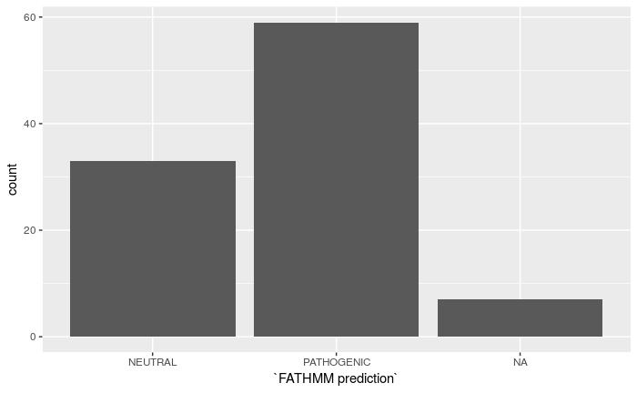

```r
ggplot(mutants, aes(x=`FATHMM prediction`)) + geom_bar()
```

`mutants` is the data that we want to plot; `FATHMM prediction` is the variable we want to show on the x-axis and `geom_bar` is the way that we want to display the data. We will re-visit other plotting types when we have imported a larger version of this dataset.

*e.g. the distribution of gene lengths*

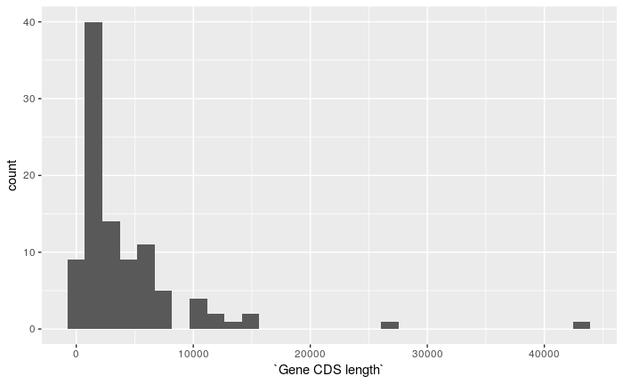

## Accessing the larger dataset

(even though the file is compressed (`.gz`) we can still read it into R)

We use the same `read_tsv` command with the path to the new file.

```r
consensus_mutants <- read_tsv("CosmicMutantExportCensus.tsv.gz")
```

The data frame object now has 700K rows

```r
consensus_mutants
```

| Gene name | Accession Number | Gene CDS length | HGNC ID | Sample name | ID_sample | ID_tumour | Primary site | Site subtype 1 | Site subtype 2 | Site subtype 3 | Primary histology | Histology subtype 1 | Histology subtype 2 | Histology subtype 3 | Genome-wide screen | Mutation ID | Mutation CDS | Mutation AA | Mutation Description | Mutation zygosity | LOH | GRCh | Mutation genome position | Mutation strand | SNP | Resistance Mutation | FATHMM prediction | FATHMM score | Mutation somatic status | … |
| --- | --- | --- | --- | --- | --- | --- | --- | --- | --- | --- | --- | --- | --- | --- | --- | --- | --- | --- | --- | --- | --- | --- | --- | --- | --- | --- | --- | --- | --- | --- |
| RNF43 | ENST00000407977 | 2352 | 18505 | T207430 | 2658236 | 2518395 | large_intestine | NS | NS | NS | carcinoma | adenocarcinoma | NS | NS | y | COSM270052 | c.1976delG | p.G659fs*41 | Deletion - Frameshift | NA | u | 38 | 17:58357800-58357800 | - | n | - | NA | NA | Confirmed somatic variant | … |
| FLT4 | ENST00000393347 | 3897 | 3767 | STC232 | 2404160 | 2267012 | stomach | NS | NS | NS | carcinoma | intestinal_adenocarcinoma | NS | NS | y | COSM5061015 | c.457G>A | p.A153T | Substitution - Missense | NA | u | 38 | 5:180630281-180630281 | - | y | - | NEUTRAL | 0.35891 | Confirmed somatic variant | … |
| TERT | ENST00000310581 | 3399 | 11730 | MBC_37 | 2662739 | 2522863 | breast | NS | NS | NS | carcinoma | basal_(triple-negative)_carcinoma | NS | NS | y | COSM6566165 | c.2422G>T | p.V808F | Substitution - Missense | NA | u | 38 | 5:1271165-1271165 | - | n | - | NEUTRAL | 0.00232 | Confirmed somatic variant | … |
| EGFR | ENST00000275493 | 3633 | 3236 | 2136631 | 2136631 | 2006182 | lung | NS | NS | NS | carcinoma | adenocarcinoma | NS | NS | n | COSM13243 | c.(2185_2283)del? | p.(729_761)del? | Deletion - In frame | NA | u | NA | NA | NA | NA | - | NA | NA | Reported in another cancer sample as somatic | … |
| RB1 | ENST00000267163 | 2787 | 9884 | T230737 | 2658264 | 2518423 | large_intestine | NS | NS | NS | carcinoma | adenocarcinoma | NS | NS | y | COSM6763475 | c.728T>C | p.V243A | Substitution - Missense | NA | u | 38 | 13:48362824-48362824 | + | n | - | PATHOGENIC | 0.86592 | Confirmed somatic variant | … |
| FOXL2 | ENST00000330315 | 1131 | 1092 | 1235921 | 1235921 | 1147684 | ovary | NS | NS | NS | sex_cord-stromal_tumour | fibroma-thecoma-fibrothecoma | NS | NS | n | COSM33661 | c.402C>G | p.C134W | Substitution - Missense | het | u | 38 | 3:138946321-138946321 | - | n | - | PATHOGENIC | 0.95436 | Confirmed somatic variant | … |
| TP53 | ENST00000269305 | 1182 | 11998 | TXJ43C | 2762704 | 2620963 | thyroid | NS | NS | NS | carcinoma | anaplastic_carcinoma | NS | NS | n | COSM10648 | c.524G>A | p.R175H | Substitution - Missense | NA | u | 38 | 17:7675088-7675088 | - | n | - | PATHOGENIC | 0.98946 | Reported in another cancer sample as somatic | … |
| HRAS | ENST00000397596 | 570 | 5173 | B54-Tumor | 2186358 | 2054655 | urinary_tract | bladder | NS | NS | carcinoma | NS | NS | NS | y | COSM486 | c.37G>C | p.G13R | Substitution - Missense | NA | u | 38 | 11:534286-534286 | - | n | - | PATHOGENIC | 0.99415 | Confirmed somatic variant | … |
| GRIN2A | ENST00000396573 | 4395 | 4585 | YUFERY | 2439313 | 2302154 | skin | NS | NS | NS | malignant_melanoma | NS | NS | NS | y | COSM5385601 | c.1773G>A | p.G591G | Substitution - coding silent | het | u | 38 | 16:9834109-9834109 | - | n | - | PATHOGENIC | 0.75623 | Confirmed somatic variant | … |
| PIK3CA | NM_006218.1 | 3207 | 8975 | P-0006183-T01-IM5 | 2722561 | 2581382 | large_intestine | colon | ascending | NS | carcinoma | adenocarcinoma | NS | NS | n | COSM767 | c.1637A>C | p.Q546P | Substitution - Missense | het | u | 38 | 3:179218307-179218307 | + | n | - | PATHOGENIC | 0.97294 | Confirmed somatic variant | … |

[output cut: 990 more lines]

The same `select`, `filter` etc operations apply.

*e.g. What mutations are recorded for `TP53`?*

```r
filter(consensus_mutants, `Gene name`=="TP53")
```

| Gene name | Accession Number | Gene CDS length | HGNC ID | Sample name | ID_sample | ID_tumour | Primary site | Site subtype 1 | Site subtype 2 | Site subtype 3 | Primary histology | Histology subtype 1 | Histology subtype 2 | Histology subtype 3 | Genome-wide screen | Mutation ID | Mutation CDS | Mutation AA | Mutation Description | Mutation zygosity | LOH | GRCh | Mutation genome position | Mutation strand | SNP | Resistance Mutation | FATHMM prediction | FATHMM score | Mutation somatic status | … |
| --- | --- | --- | --- | --- | --- | --- | --- | --- | --- | --- | --- | --- | --- | --- | --- | --- | --- | --- | --- | --- | --- | --- | --- | --- | --- | --- | --- | --- | --- | --- |
| TP53 | ENST00000269305 | 1182 | 11998 | TXJ43C | 2762704 | 2620963 | thyroid | NS | NS | NS | carcinoma | anaplastic_carcinoma | NS | NS | n | COSM10648 | c.524G>A | p.R175H | Substitution - Missense | NA | u | 38 | 17:7675088-7675088 | - | n | - | PATHOGENIC | 0.98946 | Reported in another cancer sample as somatic | … |
| TP53 | ENST00000269305 | 1182 | 11998 | MIT04-15 | 1408799 | 1318840 | liver | NS | NS | NS | carcinoma | hepatocellular_carcinoma | NS | NS | n | COSM44757 | c.586delC | p.R196fs*51 | Deletion - Frameshift | NA | u | 38 | 17:7674945-7674945 | - | n | - | NA | NA | Reported in another cancer sample as somatic | … |
| TP53 | ENST00000269305 | 1182 | 11998 | SDC28 | 2564892 | 2426286 | salivary_gland | NS | NS | NS | carcinoma | salivary_duct_carcinoma | NS | NS | n | COSM87196 | c.? | p.R248Q | Substitution - Missense | NA | u | NA | NA | NA | NA | - | NA | NA | Confirmed somatic variant | … |
| TP53 | ENST00000269305 | 1182 | 11998 | Br07X | 1312969 | 1223878 | central_nervous_system | brain | NS | NS | glioma | astrocytoma_Grade_IV | glioblastoma_multiforme | NS | n | COSM10656 | c.742C>T | p.R248W | Substitution - Missense | het | n | 38 | 17:7674221-7674221 | - | n | - | PATHOGENIC | 0.93987 | Confirmed somatic variant | … |
| TP53 | ENST00000269305 | 1182 | 11998 | P91 | 2368450 | 2231254 | large_intestine | NS | NS | NS | carcinoma | adenocarcinoma | NS | NS | n | COSM10670 | c.469G>T | p.V157F | Substitution - Missense | NA | u | 38 | 17:7675143-7675143 | - | n | - | NEUTRAL | 0.24495 | Confirmed somatic variant | … |
| TP53 | ENST00000269305 | 1182 | 11998 | 1373435 | 1373435 | 1283476 | large_intestine | NS | NS | NS | carcinoma | adenocarcinoma | NS | NS | n | COSM43617 | c.? | p.? | Unknown | NA | u | NA | NA | NA | NA | - | NA | NA | Reported in another cancer sample as somatic | … |
| TP53 | ENST00000269305 | 1182 | 11998 | 1392168 | 1392168 | 1302209 | upper_aerodigestive_tract | head_neck | NS | NS | carcinoma | squamous_cell_carcinoma | NS | NS | n | COSM43617 | c.? | p.? | Unknown | NA | u | NA | NA | NA | NA | - | NA | NA | Reported in another cancer sample as somatic | … |
| TP53 | ENST00000269305 | 1182 | 11998 | 401 | 2267373 | 2134141 | oesophagus | middle_third | NS | NS | carcinoma | squamous_cell_carcinoma | NS | NS | y | COSM1386850 | c.342G>T | p.L114F | Substitution - Missense | NA | u | 38 | 17:7676027-7676027 | - | n | - | PATHOGENIC | 0.79908 | Confirmed somatic variant | … |
| TP53 | ENST00000269305 | 1182 | 11998 | 2308766 | 2308766 | 2173969 | central_nervous_system | brain | NS | NS | glioma | astrocytoma_Grade_IV | glioblastoma_multiforme | NS | n | COSM4745860 | c.? | p.C176* | Substitution - Nonsense | NA | u | NA | NA | NA | NA | - | NA | NA | Confirmed somatic variant | … |
| TP53 | ENST00000269305 | 1182 | 11998 | L-KAW | 1375585 | 1285626 | haematopoietic_and_lymphoid_tissue | NS | NS | NS | lymphoid_neoplasm | acute_lymphoblastic_leukaemia | NS | NS | n | COSM10662 | c.743G>A | p.R248Q | Substitution - Missense | NA | u | 38 | 17:7674220-7674220 | - | n | - | PATHOGENIC | 0.98009 | Reported in another cancer sample as somatic | … |

[output cut: 990 more lines]

*e.g. What is the most commonly mutated gene in breast cancer?*

Here we can use a handy function `count` to count the number of time unique entries in a particular column occur

```r
filter(consensus_mutants, `Primary site`=="breast") %>%
  count(`Gene name`) %>%
  arrange(desc(n))
```

| Gene name | n |
| --- | --- |
| PIK3CA | 5640 |
| TP53 | 4528 |
| MED12 | 918 |
| CDH1 | 722 |
| ESR1 | 600 |
| GATA3 | 585 |
| KMT2C | 436 |
| PTEN | 386 |
| ERBB2 | 376 |
| AKT1 | 310 |

[output cut: 644 more lines]

The `%>%` operation allows us to plot that data frames that we have manipulated with `filter` etc.

*e.g. gWhat cancer types is TP53 most commonly mutated in?*

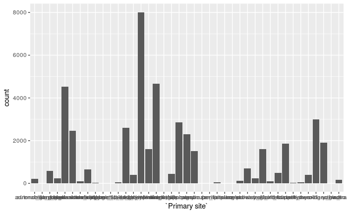

```r
filter(consensus_mutants, `Gene name`=="TP53") %>%
  ggplot(aes(x=`Primary site`)) + geom_bar()
```

There are a few too many sites to see the plot properly, so we can further filter and also flip the axis so it is easier to read

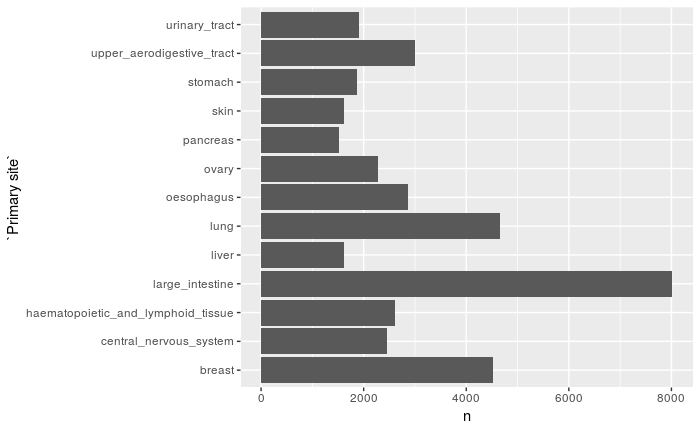

```r
filter(consensus_mutants, `Gene name`=="TP53") %>%
  count(`Primary site`) %>%
  filter(n > 1000) %>%
    ggplot(aes(x=`Primary site`,y=n)) + geom_bar(stat="identity") + coord_flip()
```

The ordering of the bars is alphabetical by default. But it is more natural to reorder according to the counts.

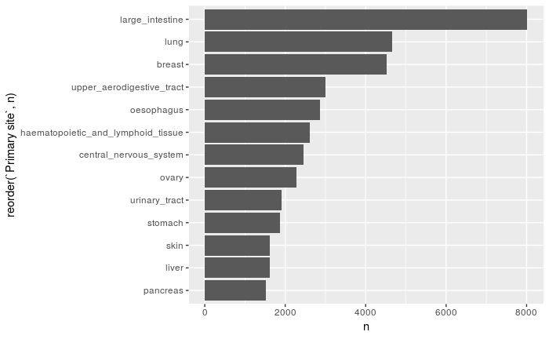

```r
filter(consensus_mutants, `Gene name`=="TP53") %>%
  count(`Primary site`) %>%
  filter(n > 1000) %>%
    ggplot(aes(x=reorder(`Primary site`,n),y=n)) + geom_bar(stat="identity") + coord_flip()
```

Do TP53 mutations have a different age distribution in different cancer types?

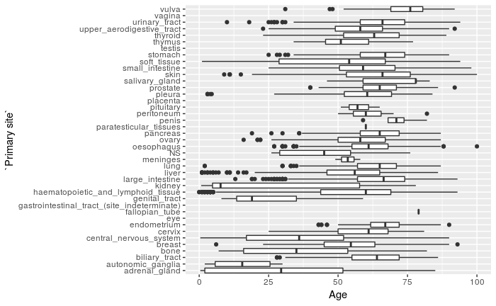

```r
filter(consensus_mutants, `Gene name`=="TP53") %>%
  ggplot(aes(x=`Primary site`,y=Age)) + geom_boxplot() + coord_flip()
```

# Annotating vcf files

We will use the somatic calls that have previously been made for the *HCC1143* breast cancer cell line. The calls were made as part of a [Cancer Research Uk Bioinformatics Summer School](https://bioinformatics-core-shared-training.github.io/cruk-summer-school-2016/).

The following workflow including tools from the Bioconductor project will be used

- importing raw vcf calls with `VariantAnnotation`
- use the transcript database package `TxDb....` to annotate variants within coding regions
- use the genome sequence package `Bsgenome....` to assess function
- use the genome annotation package `org.Hs.eg.db` to convert to between identifiers
- join the tables with `dplyr` and use the functions from the previous section

First we need to download the file and save locally.

```r
url <- "https://github.com/bioinformatics-core-shared-training/cruk-summer-school-2016/raw/master/Day3/HCC1143_vs_HCC1143_BL.flagged.muts.vcf"
download.file(url, destfile="HCC1143_vs_HCC1143_BL.flagged.muts.vcf")
```

Unlike a data frame, the whole object does not get printed to the screen we type `raw_vcf` and execute.

```r
raw_vcf
```

```
class: CollapsedVCF
dim: 92286 2
rowRanges(vcf):
  GRanges with 5 metadata columns: paramRangeID, REF, ALT, QUAL, FILTER
info(vcf):
  DataFrame with 12 columns: DP, MP, GP, TG, TP, SG, SP, DS, SNP, ASRD, CLPM, ASMD
info(header(vcf)):
        Number Type    Description
   DP   1      Integer Total Depth
   MP   1      Float   Sum of CaVEMan somatic genotype probabilities
   GP   1      Float   Sum of CaVEMan germline genotype probabilities
   TG   1      String  Most probable genotype as called by CaVEMan
   TP   1      Float   Probability of most probable genotype as called by CaVEMan
   SG   1      String  2nd most probable genotype as called by CaVEMan
   SP   1      Float   Probability of 2nd most probable genotype as called by CaVEMan
   DS   .      String  DBSnp ID of known SNP
   SNP  0      Flag    Position matches a dbSNP entry using the supplied bed file
   ASRD 1      Float   A soft flag median (read length adjusted) alignment score of reads showing the variant allele
   CLPM 1      Float   A soft flag median number of soft clipped bases in variant supporting reads
   ASMD 1      Float   A soft flag median alignement score of reads showing the variant allele
geno(vcf):
  SimpleList of length 10: GT, FAZ, FCZ, FGZ, FTZ, RAZ, RCZ, RGZ, RTZ, PM
geno(header(vcf)):
       Number Type    Description
   GT  1      String  Genotype
   FAZ 1      Integer Reads presenting a A for this position, forward strand
   FCZ 1      Integer Reads presenting a C for this position, forward strand
   FGZ 1      Integer Reads presenting a G for this position, forward strand
   FTZ 1      Integer Reads presenting a T for this position, forward strand
   RAZ 1      Integer Reads presenting a A for this position, reverse strand
   RCZ 1      Integer Reads presenting a C for this position, reverse strand
   RGZ 1      Integer Reads presenting a G for this position, reverse strand
   RTZ 1      Integer Reads presenting a T for this position, reverse strand
   PM  1      Float   Proportion of mut allele
```

To make the process go more smoothly, we will consider variants on chromosomes 1 to 22 only. The naming convention of the chromosomes also needs to be changed to be compatible with the annotation resources we are going to use.

```r
raw_vcf <- keepSeqlevels(raw_vcf, 1:22,pruning.mode = "coarse")
seqlevelsStyle(raw_vcf) <- "UCSC"
genome(raw_vcf) <- "hg19"
```

The data from the vcf file has been separated into different parts of the object that can be accessed by a series of functions. The location of the variants can be returned using the `rowRanges` function that is part of `VariantAnnotation`.

```r
var_locs <- rowRanges(raw_vcf)
var_locs
```

```
GRanges object with 87753 ranges and 5 metadata columns:
                                       seqnames               ranges strand | paramRangeID            REF                ALT      QUAL
                                          <Rle>            <IRanges>  <Rle> |     <factor> <DNAStringSet> <DNAStringSetList> <numeric>
  6c54cf8c-3ee9-11e6-9d63-a89a8835fc03     chr1     [ 16103,  16103]      * |         <NA>              T                  G      <NA>
  6c54d310-3ee9-11e6-9d63-a89a8835fc03     chr1     [ 17222,  17222]      * |         <NA>              A                  G      <NA>
  6c54d3ce-3ee9-11e6-9d63-a89a8835fc03     chr1     [ 74570,  74570]      * |         <NA>              T                  A      <NA>
  6c54d46e-3ee9-11e6-9d63-a89a8835fc03     chr1     [101445, 101445]      * |         <NA>              G                  C      <NA>
  6c54d504-3ee9-11e6-9d63-a89a8835fc03     chr1     [101456, 101456]      * |         <NA>              A                  G      <NA>
                                   ...      ...                  ...    ... .          ...            ...                ...       ...
  6dc4437a-3ee9-11e6-9d63-a89a8835fc03    chr22 [51192990, 51192990]      * |         <NA>              C                  A      <NA>
  6dc44406-3ee9-11e6-9d63-a89a8835fc03    chr22 [51238839, 51238839]      * |         <NA>              C                  T      <NA>
  6dc44492-3ee9-11e6-9d63-a89a8835fc03    chr22 [51238846, 51238846]      * |         <NA>              G                  A      <NA>
  6dc44528-3ee9-11e6-9d63-a89a8835fc03    chr22 [51239025, 51239025]      * |         <NA>              C                  T      <NA>
  6dc445b4-3ee9-11e6-9d63-a89a8835fc03    chr22 [51239040, 51239040]      * |         <NA>              G                  A      <NA>
                                              FILTER
                                         <character>
  6c54cf8c-3ee9-11e6-9d63-a89a8835fc03     VUM;MQ;MN
  6c54d310-3ee9-11e6-9d63-a89a8835fc03 MNP;VUM;MQ;MN
  6c54d3ce-3ee9-11e6-9d63-a89a8835fc03        MQ;VUM
  6c54d46e-3ee9-11e6-9d63-a89a8835fc03        MQ;MNP
  6c54d504-3ee9-11e6-9d63-a89a8835fc03        MNP;MQ
                                   ...           ...
  6dc4437a-3ee9-11e6-9d63-a89a8835fc03           MNP
  6dc44406-3ee9-11e6-9d63-a89a8835fc03            MQ
  6dc44492-3ee9-11e6-9d63-a89a8835fc03         RP;MQ
  6dc44528-3ee9-11e6-9d63-a89a8835fc03     MQ;MNP;MN
  6dc445b4-3ee9-11e6-9d63-a89a8835fc03         MN;MQ
  -------
  seqinfo: 22 sequences from hg19 genome
```

We notice that the vcf file already has some filters applied for quality. Variants that pass all the filters have an entry of `PASS`. We will use these variants in subsequent analyses.

N.B. the data aren’t yet in a form that we can use the `dplyr` operations from previously, so we have to use a different approach to filter the rows.

```r
pass_vcf <- raw_vcf[var_locs$FILTER == "PASS"]
pass_locs <- rowRanges(pass_vcf)
```

The Bioconductor project also distributes several annotation packages that can be used to annotate our results. The collection of `TxDb....` packages comprise definitions of transcripts for a given genome build.

```r
library(TxDb.Hsapiens.UCSC.hg19.knownGene)
```

[output not shown]

The `locateVariants` function can be used to find where the variants are located with respect to different types of genomic feature. Various types of match including `CodingVariants` that will find variants inside coding regions. The output is converted to a data frame so we can use the `dplyr` functions we saw earlier

We clean-up the output so only certain columns are displayed. The `QUERYID` column needs to be kept to refer back to the complete set of variants in the filtered vcf file. The `GENEID` column will be used later to map to other annotation resources.

```r
var_annotations <- locateVariants(pass_locs, txdb, CodingVariants())
var_annotations <- as.data.frame(var_annotations) %>%
  dplyr::select(QUERYID,GENEID) %>% unique %>%
  filter(!is.na(GENEID))
var_annotations
```

[output not shown]

With the `predictCoding` function we can assess whether the mutations are going to result in amino acid change or not. This makes use of the Genome sequence, which is available in the `BSgenome.Hsapiens.UCSC.hg19` package.

Again we only use certain columns from the output.

```r
library(BSgenome.Hsapiens.UCSC.hg19)
var_predictions <- predictCoding(pass_vcf, txdb, seqSource = Hsapiens)
names(var_predictions) <- make.names(names(var_predictions),unique = TRUE)
var_predictions <- as.data.frame(var_predictions) %>%
  dplyr::select(QUERYID,CONSEQUENCE,REFCODON,VARCODON,REFAA,VARAA) %>% unique
var_predictions
```

[output not shown]

Now the data are in data frames, we can join the two tables together with `dplyr`.

```r
var_annotations <- left_join(var_annotations,var_predictions,by="QUERYID")
var_annotations
```

[output not shown]

The gene names are currently Entrez ID, which although useful for mapping, do not give particularly memorable names that we can search for. We use a pre-built annotation package `org.Hs.eg.db` to obtain gene symbols.

```r
library(org.Hs.eg.db)
gene_anno <- AnnotationDbi::select(org.Hs.eg.db,
                                   columns="SYMBOL",
                                   keys=var_annotations$GENEID,
                                   keytype = "ENTREZID")
gene_anno <- dplyr::rename(gene_anno, "GENEID"=ENTREZID)

var_annotations <- left_join(var_annotations, gene_anno) %>% unique
var_annotations
```

[output not shown]

We can put everything together into one table. The locations from the vcf need to be converted into a data frame including a `QUERYID` column that can be matched to the annotations. This is defined to be the row number.

```r
final_tab <- as.data.frame(pass_locs) %>%
  mutate(QUERYID = 1:n()) %>% dplyr::select(-width,-paramRangeID,-ALT,-QUAL,-FILTER,-strand) %>%
  inner_join(var_annotations, by="QUERYID") %>%
  dplyr::select(seqnames:end,SYMBOL,REF:VARAA,-QUERYID)
final_tab
```

[output not shown]

The `dplyr` functions and `ggplot2` introduced in the previous section can now be applied to our list of variants.

```r
filter(final_tab, CONSEQUENCE=="nonsense")
```

[output not shown]

What genes are most commonly mutated?

```r
dplyr::count(final_tab, SYMBOL) %>% arrange(desc(n))
```

[output not shown]

How many variants are located on each chromosome?

```r
ggplot(final_tab, aes(x=seqnames,fill=CONSEQUENCE)) + geom_bar(position="dodge") + coord_flip()
```

[output not shown]